[View on GitHub](https://github.com/joshmaglione/CS102-Jupyter/blob/main/07_DataFrames.ipynb)

# 07 : Working with DataFrames

## Learning outcomes

- Load tabular data into `DataFrame`s and inspect structure.
- Filter, sort, and transform data to answer focused questions.
- Combine datasets and produce clean summary tables for analysis.

Last time we discussed the three main data structures `pandas` brings.

Now we will discuss how to manipulate the primary object: DataFrames.

Let's load in UN data about Ireland from two files sources:

- `data/01_below_poverty.csv`
- `data/07_renewable_energy.csv`

(This was obtained from the [United Nations' SDG Country Profile Page](https://unstats.un.org/sdgs/dataportal/countryprofiles/IRL))

This data has lots of information that we don't need, so our goal is to produce one DataFrame with the information we want.

```python
import numpy as np
import pandas as pd
print(f"pandas version: {pd.__version__}")
```

```
pandas version: 2.2.3
```

You can [read more](https://pandas.pydata.org/pandas-docs/stable/user_guide/copy_on_write.html#copy-on-write) about their upcoming changes to `pandas 3.0`.

## Below Poverty Data Set

We'll work through some of the basics with the below poverty data set.

```python
df1 = pd.read_csv("data/01_below_poverty.csv")
df1.head()
```

|  | Goal | Target | Indicator | SeriesCode | SeriesDescription | GeoAreaCode | GeoAreaName | TimePeriod | Value | Time_Detail | ... | BasePeriod | Source | GeoInfoUrl | FootNote | Age | Location | Nature | Reporting Type | Sex | Units |
| --- | --- | --- | --- | --- | --- | --- | --- | --- | --- | --- | --- | --- | --- | --- | --- | --- | --- | --- | --- | --- | --- |
| 0 | 1.0 | 1.1 | 1.1.1 | SI_POV_DAY1 | Proportion of population below international p... | 372.0 | Ireland | 1987.0 | 0.7 | 1987.0 | ... | 2017.0 | Poverty and Inequality Portal, World Bank | NaN | Accessed March 21, 2023. Based on data from SI... | ALLAGE | ALLAREA | G | G | BOTHSEX | PERCENT |
| 1 | 1.0 | 1.1 | 1.1.1 | SI_POV_DAY1 | Proportion of population below international p... | 372.0 | Ireland | 1994.0 | 0.2 | 1994.0 | ... | 2017.0 | Poverty and Inequality Portal, World Bank | NaN | Accessed March 21, 2023. Based on data from LI... | ALLAGE | ALLAREA | G | G | BOTHSEX | PERCENT |
| 2 | 1.0 | 1.1 | 1.1.1 | SI_POV_DAY1 | Proportion of population below international p... | 372.0 | Ireland | 1995.0 | 0.2 | 1995.0 | ... | 2017.0 | Poverty and Inequality Portal, World Bank | NaN | Accessed March 21, 2023. Based on data from LI... | ALLAGE | ALLAREA | G | G | BOTHSEX | PERCENT |
| 3 | 1.0 | 1.1 | 1.1.1 | SI_POV_DAY1 | Proportion of population below international p... | 372.0 | Ireland | 1996.0 | 0.2 | 1996.0 | ... | 2017.0 | Poverty and Inequality Portal, World Bank | NaN | Accessed March 21, 2023. Based on data from LI... | ALLAGE | ALLAREA | G | G | BOTHSEX | PERCENT |
| 4 | 1.0 | 1.1 | 1.1.1 | SI_POV_DAY1 | Proportion of population below international p... | 372.0 | Ireland | 2000.0 | 0.2 | 2000.0 | ... | 2017.0 | Poverty and Inequality Portal, World Bank | NaN | Accessed March 21, 2023. Based on data from LI... | ALLAGE | ALLAREA | G | G | BOTHSEX | PERCENT |

5 rows × 23 columns

Most of the columns look irrelevant. Let's look to keep the columns

- "TimePeriod"
- "Value"
- "Time_Detail"
- "Age"
- "Location"
- "Sex"

```python
df1 = df1[[
	"TimePeriod",
	"Value",
	"Time_Detail",
	"Age",
	"Location",
	"Sex"
]]
df1
```

|  | TimePeriod | Value | Time_Detail | Age | Location | Sex |
| --- | --- | --- | --- | --- | --- | --- |
| 0 | 1987.0 | 0.70000 | 1987.0 | ALLAGE | ALLAREA | BOTHSEX |
| 1 | 1994.0 | 0.20000 | 1994.0 | ALLAGE | ALLAREA | BOTHSEX |
| 2 | 1995.0 | 0.20000 | 1995.0 | ALLAGE | ALLAREA | BOTHSEX |
| 3 | 1996.0 | 0.20000 | 1996.0 | ALLAGE | ALLAREA | BOTHSEX |
| 4 | 2000.0 | 0.20000 | 2000.0 | ALLAGE | ALLAREA | BOTHSEX |
| ... | ... | ... | ... | ... | ... | ... |
| 146 | 2020.0 | 0.08503 | 2020.0 | <15Y | ALLAREA | BOTHSEX |
| 147 | 2020.0 | 0.10854 | 2020.0 | ALLAGE | URBAN | BOTHSEX |
| 148 | 2020.0 | 0.19978 | 2020.0 | ALLAGE | RURAL | BOTHSEX |
| 149 | 2020.0 | 0.09574 | 2020.0 | ALLAGE | ALLAREA | MALE |
| 150 | NaN | NaN | NaN | NaN | NaN | NaN |

151 rows × 6 columns

It's weird that `"TimePeriod"` is a float. Let's change this to an int.

```python
df1.astype({"TimePeriod" : "i"})
```

[output not shown]

[output cut: 34 more lines]

[output not shown]

We need to clean our data before we can manipulate it. Let's remove the rows where `"TimePeriod"` is empty.

```python
df1 = df1.dropna(subset="TimePeriod")
df1 = df1.astype({"TimePeriod" : "i"})
df1.loc[22]
```

```
TimePeriod        2005
Value              0.0
Time_Detail     2005.0
Age             ALLAGE
Location       ALLAREA
Sex            BOTHSEX
Name: 22, dtype: object
```

We are not going to span the entirity of this data set. Let's just take the years 2005 to 2020.

We'll do this with the [`query`](https://pandas.pydata.org/docs/reference/api/pandas.DataFrame.query.html) command.

At a basic level it takes a string that appropriately masks part of the dataframe.

By default, `query` is a copy, unlike slicing in `ndarray` which yields a view.

```python
df1_check = df1.query("2005 <= TimePeriod <= 2020")
df1.at[22, "TimePeriod"] = 1000     # Index 22 is the first row with 2005
df1.loc[22]
```

```
TimePeriod        1000
Value              0.0
Time_Detail     2005.0
Age             ALLAGE
Location       ALLAREA
Sex            BOTHSEX
Name: 22, dtype: object
```

```python
df1_check
```

|  | TimePeriod | Value | Time_Detail | Age | Location | Sex |
| --- | --- | --- | --- | --- | --- | --- |
| 22 | 2005 | 0.00000 | 2005.0 | ALLAGE | ALLAREA | BOTHSEX |
| 23 | 2005 | 0.03139 | 2005.0 | 15-64 | ALLAREA | BOTHSEX |
| 24 | 2005 | 0.03699 | 2005.0 | 65+ | ALLAREA | BOTHSEX |
| 25 | 2005 | 0.02371 | 2005.0 | ALLAGE | ALLAREA | FEMALE |
| 26 | 2005 | 0.03108 | 2005.0 | ALLAGE | ALLAREA | MALE |
| ... | ... | ... | ... | ... | ... | ... |
| 145 | 2020 | 0.15064 | 2020.0 | 15-64 | ALLAREA | BOTHSEX |
| 146 | 2020 | 0.08503 | 2020.0 | <15Y | ALLAREA | BOTHSEX |
| 147 | 2020 | 0.10854 | 2020.0 | ALLAGE | URBAN | BOTHSEX |
| 148 | 2020 | 0.19978 | 2020.0 | ALLAGE | RURAL | BOTHSEX |
| 149 | 2020 | 0.09574 | 2020.0 | ALLAGE | ALLAREA | MALE |

128 rows × 6 columns

```python
df1 = df1_check
```

The `"Time_Detail"` column looks irrelevant.

Let's look at all the values and the number of time they arise with [`value_counts`](https://pandas.pydata.org/pandas-docs/stable/reference/api/pandas.Series.value_counts.html).

```python
df1["Time_Detail"].value_counts()
```

```
Time_Detail
2005.0    8
2006.0    8
2007.0    8
2008.0    8
2009.0    8
2010.0    8
2011.0    8
2012.0    8
2013.0    8
2014.0    8
2015.0    8
2016.0    8
2017.0    8
2018.0    8
2019.0    8
2020.0    8
Name: count, dtype: int64
```

```python
df1 = df1.drop(["Time_Detail"], axis=1)
df1
```

|  | TimePeriod | Value | Age | Location | Sex |
| --- | --- | --- | --- | --- | --- |
| 22 | 2005 | 0.00000 | ALLAGE | ALLAREA | BOTHSEX |
| 23 | 2005 | 0.03139 | 15-64 | ALLAREA | BOTHSEX |
| 24 | 2005 | 0.03699 | 65+ | ALLAREA | BOTHSEX |
| 25 | 2005 | 0.02371 | ALLAGE | ALLAREA | FEMALE |
| 26 | 2005 | 0.03108 | ALLAGE | ALLAREA | MALE |
| ... | ... | ... | ... | ... | ... |
| 145 | 2020 | 0.15064 | 15-64 | ALLAREA | BOTHSEX |
| 146 | 2020 | 0.08503 | <15Y | ALLAREA | BOTHSEX |
| 147 | 2020 | 0.10854 | ALLAGE | URBAN | BOTHSEX |
| 148 | 2020 | 0.19978 | ALLAGE | RURAL | BOTHSEX |
| 149 | 2020 | 0.09574 | ALLAGE | ALLAREA | MALE |

128 rows × 5 columns

- "Age"
- "Location"
- "Sex"

We want the most inclusive options.

Let's look at the rows for one particular year.

```python
df1.query("2011 == TimePeriod")
```

|  | TimePeriod | Value | Age | Location | Sex |
| --- | --- | --- | --- | --- | --- |
| 70 | 2011 | 0.50000 | ALLAGE | ALLAREA | BOTHSEX |
| 71 | 2011 | 0.08366 | <15Y | ALLAREA | BOTHSEX |
| 72 | 2011 | 0.67060 | 15-64 | ALLAREA | BOTHSEX |
| 73 | 2011 | 0.65755 | 65+ | ALLAREA | BOTHSEX |
| 74 | 2011 | 0.40174 | ALLAGE | ALLAREA | FEMALE |
| 75 | 2011 | 0.69121 | ALLAGE | ALLAREA | MALE |
| 76 | 2011 | 0.59732 | ALLAGE | RURAL | BOTHSEX |
| 77 | 2011 | 0.51095 | ALLAGE | URBAN | BOTHSEX |

The data set has lots of granularity. Let's just take the coarse, general information.

We'll do this by chaining three queries.

In comments, we have an equivalent version, but it is generally considered good practice to chain as follows.

*This is just for aesthetic and reabability reasons.*

```python
# df1 = df1[
# 	(df1["Age"] == "ALLAGE") &
# 	(df1["Location"] == "ALLAREA") &
# 	(df1["Sex"] == "BOTHSEX")
# ]
df1 = (df1
    .query("Age == 'ALLAGE'")
    .query("Location == 'ALLAREA'")
    .query("Sex == 'BOTHSEX'")
)
df1
```

|  | TimePeriod | Value | Age | Location | Sex |
| --- | --- | --- | --- | --- | --- |
| 22 | 2005 | 0.0 | ALLAGE | ALLAREA | BOTHSEX |
| 37 | 2006 | 0.4 | ALLAGE | ALLAREA | BOTHSEX |
| 38 | 2007 | 0.1 | ALLAGE | ALLAREA | BOTHSEX |
| 53 | 2008 | 0.2 | ALLAGE | ALLAREA | BOTHSEX |
| 54 | 2009 | 0.5 | ALLAGE | ALLAREA | BOTHSEX |
| 69 | 2010 | 0.5 | ALLAGE | ALLAREA | BOTHSEX |
| 70 | 2011 | 0.5 | ALLAGE | ALLAREA | BOTHSEX |
| 79 | 2012 | 0.3 | ALLAGE | ALLAREA | BOTHSEX |
| 93 | 2013 | 0.7 | ALLAGE | ALLAREA | BOTHSEX |
| 94 | 2014 | 0.4 | ALLAGE | ALLAREA | BOTHSEX |
| 109 | 2015 | 0.4 | ALLAGE | ALLAREA | BOTHSEX |
| 110 | 2016 | 0.1 | ALLAGE | ALLAREA | BOTHSEX |
| 125 | 2017 | 0.2 | ALLAGE | ALLAREA | BOTHSEX |
| 126 | 2018 | 0.0 | ALLAGE | ALLAREA | BOTHSEX |
| 141 | 2019 | 0.1 | ALLAGE | ALLAREA | BOTHSEX |
| 142 | 2020 | 0.1 | ALLAGE | ALLAREA | BOTHSEX |

Now that the last three columns are constant, we will drop them.

```python
df1 = df1.drop(["Age", "Location", "Sex"], axis=1)
df1
```

|  | TimePeriod | Value |
| --- | --- | --- |
| 22 | 2005 | 0.0 |
| 37 | 2006 | 0.4 |
| 38 | 2007 | 0.1 |
| 53 | 2008 | 0.2 |
| 54 | 2009 | 0.5 |
| 69 | 2010 | 0.5 |
| 70 | 2011 | 0.5 |
| 79 | 2012 | 0.3 |
| 93 | 2013 | 0.7 |
| 94 | 2014 | 0.4 |
| 109 | 2015 | 0.4 |
| 110 | 2016 | 0.1 |
| 125 | 2017 | 0.2 |
| 126 | 2018 | 0.0 |
| 141 | 2019 | 0.1 |
| 142 | 2020 | 0.1 |

The current index is also irrelevant. Let's convert `"TimePeriod"` to our index.

```python
df1 = df1.set_index("TimePeriod")
df1
```

| TimePeriod | Value |
| --- | --- |
| 2005 | 0.0 |
| 2006 | 0.4 |
| 2007 | 0.1 |
| 2008 | 0.2 |
| 2009 | 0.5 |
| 2010 | 0.5 |
| 2011 | 0.5 |
| 2012 | 0.3 |
| 2013 | 0.7 |
| 2014 | 0.4 |
| 2015 | 0.4 |
| 2016 | 0.1 |
| 2017 | 0.2 |
| 2018 | 0.0 |
| 2019 | 0.1 |
| 2020 | 0.1 |

Lastly, let's change `"Value"` to `"Below Poverty (%)"`.

```python
df1 = df1.rename(columns={"Value" : "Below Poverty (%)"})
df1
```

| TimePeriod | Below Poverty (%) |
| --- | --- |
| 2005 | 0.0 |
| 2006 | 0.4 |
| 2007 | 0.1 |
| 2008 | 0.2 |
| 2009 | 0.5 |
| 2010 | 0.5 |
| 2011 | 0.5 |
| 2012 | 0.3 |
| 2013 | 0.7 |
| 2014 | 0.4 |
| 2015 | 0.4 |
| 2016 | 0.1 |
| 2017 | 0.2 |
| 2018 | 0.0 |
| 2019 | 0.1 |
| 2020 | 0.1 |

## Speedrun: Renewable Energy Data Set

We will basically do the same steps as above, but all at once. See if you can follow along line by line.

```python
df2 = pd.read_csv("data/07_renewable_energy.csv")
df2 = df2[["TimePeriod", "Value"]]
df2 = df2.dropna()
df2 = df2.astype({"TimePeriod" : "i"})
df2 = df2.set_index("TimePeriod")
df2 = df2.loc["2005":"2020"]
df2 = df2.rename(columns={"Value" : "Renewable Energy Share (%)"})
df2
```

| TimePeriod | Renewable Energy Share (%) |
| --- | --- |
| 2005 | 2.89 |
| 2006 | 3.23 |
| 2007 | 3.55 |
| 2008 | 4.19 |
| 2009 | 5.30 |
| 2010 | 5.29 |
| 2011 | 6.96 |
| 2012 | 6.90 |
| 2013 | 7.71 |
| 2014 | 8.78 |
| 2015 | 9.52 |
| 2016 | 8.61 |
| 2017 | 10.11 |
| 2018 | 10.83 |
| 2019 | 12.33 |
| 2020 | 13.69 |

## From two to one

Because our two DataFrames have the same index, we can concatenate them in `pandas`.

```python
df = pd.concat([df1, df2], axis=1)		# Merging our two DataFrames
df.index.names = ["Year"]				# Renaming the index
df
```

| Year | Below Poverty (%) | Renewable Energy Share (%) |
| --- | --- | --- |
| 2005 | 0.0 | 2.89 |
| 2006 | 0.4 | 3.23 |
| 2007 | 0.1 | 3.55 |
| 2008 | 0.2 | 4.19 |
| 2009 | 0.5 | 5.30 |
| 2010 | 0.5 | 5.29 |
| 2011 | 0.5 | 6.96 |
| 2012 | 0.3 | 6.90 |
| 2013 | 0.7 | 7.71 |
| 2014 | 0.4 | 8.78 |
| 2015 | 0.4 | 9.52 |
| 2016 | 0.1 | 8.61 |
| 2017 | 0.2 | 10.11 |
| 2018 | 0.0 | 10.83 |
| 2019 | 0.1 | 12.33 |
| 2020 | 0.1 | 13.69 |

We can get some quick statistics on our data.

```python
df.describe()
print(df.median()["Below Poverty (%)"])
```

```
0.25
```

#### Detour: visualization

We'll discuss this more later, but we can now plot the DataFrame on a set of axes with `Matplotlib` (working in the background).

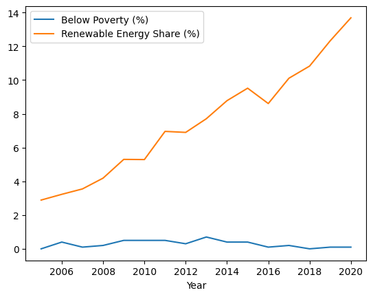

```python
df.plot()
```

## Ufuncs

All the `NumPy` UFuncs can be applied to DataFrames, provided they are applied to appropriate numerical data.

First let's generate some random data.

```python
N = 5

# Generate some random data with N + 1 rows
IDs = np.arange(2*N)
np.random.shuffle(IDs)
ID1 = IDs[:N + 1].copy()
ID1.sort()
df1 = np.floor(pd.DataFrame({
	"Height (cm)" : np.random.normal(168, 8, N + 1),
	"Weight (km)" : np.random.normal(82, 9, N + 1),
}, index=ID1)).astype("i")
df1
```

|  | Height (cm) | Weight (km) |
| --- | --- | --- |
| 0 | 164 | 82 |
| 1 | 160 | 95 |
| 2 | 156 | 87 |
| 3 | 170 | 84 |
| 5 | 166 | 95 |
| 7 | 197 | 83 |

```python
# Generate more random data with N + 2 rows
np.random.shuffle(IDs)
ID2 = IDs[:N + 2].copy()
ID2.sort()
df2 = np.floor(pd.DataFrame({
	"Age (y)" : np.random.normal(40, 5, N + 2),
	"Heart rate (bpm)" : np.random.normal(78, 9, N + 2),
}, index=ID2)).astype("i")
df2
```

|  | Age (y) | Heart rate (bpm) |
| --- | --- | --- |
| 0 | 41 | 65 |
| 1 | 35 | 94 |
| 2 | 37 | 65 |
| 5 | 34 | 72 |
| 7 | 38 | 81 |
| 8 | 37 | 75 |
| 9 | 39 | 87 |

By using Ufuncs on Series, we can compute a BMI column in the first data set.

```python
df1["BMI"] = np.round(df1["Weight (km)"] / (df1["Height (cm)"]/100)**2).astype("i")
df1
```

|  | Height (cm) | Weight (km) | BMI |
| --- | --- | --- | --- |
| 0 | 164 | 82 | 30 |
| 1 | 160 | 95 | 37 |
| 2 | 156 | 87 | 36 |
| 3 | 170 | 84 | 29 |
| 5 | 166 | 95 | 34 |
| 7 | 197 | 83 | 21 |

Before we continue to, it will be useful to use the following utility function.

```python
class display(object):
    """Display HTML representation of multiple objects"""
    template = """<div style="float: left; padding: 10px;">
    <p style='font-family:"Courier New", Courier, monospace'>{0}</p>{1}
    </div>"""
    def __init__(self, *args):
        self.args = args

    def _repr_html_(self):
        return '\n'.join(self.template.format(a, eval(a)._repr_html_())
                         for a in self.args)

    def __repr__(self):
        return '\n\n'.join(a + '\n' + repr(eval(a))
                           for a in self.args)
```

## Concatenation

We have already seen a special case of concatenation, but that had the benefit of having indices the same.

We can concatenate the two dataframes to get

```python
pd.concat([df1, df2], axis=1, sort=True)
```

|  | Height (cm) | Weight (km) | BMI | Age (y) | Heart rate (bpm) |
| --- | --- | --- | --- | --- | --- |
| 0 | 164.0 | 82.0 | 30.0 | 41.0 | 65.0 |
| 1 | 160.0 | 95.0 | 37.0 | 35.0 | 94.0 |
| 2 | 156.0 | 87.0 | 36.0 | 37.0 | 65.0 |
| 3 | 170.0 | 84.0 | 29.0 | NaN | NaN |
| 5 | 166.0 | 95.0 | 34.0 | 34.0 | 72.0 |
| 7 | 197.0 | 83.0 | 21.0 | 38.0 | 81.0 |
| 8 | NaN | NaN | NaN | 37.0 | 75.0 |
| 9 | NaN | NaN | NaN | 39.0 | 87.0 |

We may want to *exclude* those rows that are not complete. We can do this by setting `join="inner"`.

```python
pd.concat([df1, df2], axis=1, join="inner", sort=True)
```

|  | Height (cm) | Weight (km) | BMI | Age (y) | Heart rate (bpm) |
| --- | --- | --- | --- | --- | --- |
| 0 | 164 | 82 | 30 | 41 | 65 |
| 1 | 160 | 95 | 37 | 35 | 94 |
| 2 | 156 | 87 | 36 | 37 | 65 |
| 5 | 166 | 95 | 34 | 34 | 72 |
| 7 | 197 | 83 | 21 | 38 | 81 |

The default is `join="outer"`.

Another example taken from the [documentation](https://pandas.pydata.org/pandas-docs/stable/user_guide/merging.html#joining-logic-of-the-resulting-axis).

```python
dfa = pd.DataFrame(
    {
        "A": ["A0", "A1", "A2", "A3"],
        "B": ["B0", "B1", "B2", "B3"],
        "C": ["C0", "C1", "C2", "C3"],
        "D": ["D0", "D1", "D2", "D3"],
    },
    index=[0, 1, 2, 3],
)

dfb = pd.DataFrame(
    {
        "B": ["B2", "B3", "B6", "B7"],
        "D": ["D2", "D3", "D6", "D7"],
        "F": ["F2", "F3", "F6", "F7"],
    },
    index=[2, 3, 6, 7],
)

result = pd.concat([dfa, dfb], axis=1)
```

```python
display('dfa', 'dfb', 'result')
```

dfa

|  | A | B | C | D |
| --- | --- | --- | --- | --- |
| 0 | A0 | B0 | C0 | D0 |
| 1 | A1 | B1 | C1 | D1 |
| 2 | A2 | B2 | C2 | D2 |
| 3 | A3 | B3 | C3 | D3 |

dfb

|  | B | D | F |
| --- | --- | --- | --- |
| 2 | B2 | D2 | F2 |
| 3 | B3 | D3 | F3 |
| 6 | B6 | D6 | F6 |
| 7 | B7 | D7 | F7 |

result

|  | A | B | C | D | B | D | F |
| --- | --- | --- | --- | --- | --- | --- | --- |
| 0 | A0 | B0 | C0 | D0 | NaN | NaN | NaN |
| 1 | A1 | B1 | C1 | D1 | NaN | NaN | NaN |
| 2 | A2 | B2 | C2 | D2 | B2 | D2 | F2 |
| 3 | A3 | B3 | C3 | D3 | B3 | D3 | F3 |
| 6 | NaN | NaN | NaN | NaN | B6 | D6 | F6 |
| 7 | NaN | NaN | NaN | NaN | B7 | D7 | F7 |

## Merging

Merging is similar to concatenation, but significantly different. 😅

```python
display('dfa', 'dfb', 'dfa.merge(dfb)')
```

dfa

|  | A | B | C | D |
| --- | --- | --- | --- | --- |
| 0 | A0 | B0 | C0 | D0 |
| 1 | A1 | B1 | C1 | D1 |
| 2 | A2 | B2 | C2 | D2 |
| 3 | A3 | B3 | C3 | D3 |

dfb

|  | B | D | F |
| --- | --- | --- | --- |
| 2 | B2 | D2 | F2 |
| 3 | B3 | D3 | F3 |
| 6 | B6 | D6 | F6 |
| 7 | B7 | D7 | F7 |

dfa.merge(dfb)

|  | A | B | C | D | F |
| --- | --- | --- | --- | --- | --- |
| 0 | A2 | B2 | C2 | D2 | F2 |
| 1 | A3 | B3 | C3 | D3 | F3 |

Unlike with concatenation, DataFrames are joined by default using `'inner'`, but with the `how` keyword argument.

With `merge`, there are many more options. One can set `how` to be:

- `inner`
- `outer`
- `left`
- `right`
- `cross`

```python
display('dfa', 'dfb', 'dfa.merge(dfb, how="right")')
```

dfa

|  | A | B | C | D |
| --- | --- | --- | --- | --- |
| 0 | A0 | B0 | C0 | D0 |
| 1 | A1 | B1 | C1 | D1 |
| 2 | A2 | B2 | C2 | D2 |
| 3 | A3 | B3 | C3 | D3 |

dfb

|  | B | D | F |
| --- | --- | --- | --- |
| 2 | B2 | D2 | F2 |
| 3 | B3 | D3 | F3 |
| 6 | B6 | D6 | F6 |
| 7 | B7 | D7 | F7 |

dfa.merge(dfb, how="right")

|  | A | B | C | D | F |
| --- | --- | --- | --- | --- | --- |
| 0 | A2 | B2 | C2 | D2 | F2 |
| 1 | A3 | B3 | C3 | D3 | F3 |
| 2 | NaN | B6 | NaN | D6 | F6 |
| 3 | NaN | B7 | NaN | D7 | F7 |

By default, the largest set of compatible columns are choosen.

We can merge on fewer columns by changing the `on` keyword argument.

```python
display('dfa', 'dfb', 'dfa.merge(dfb, how="outer", on="B")')
```

dfa

|  | A | B | C | D |
| --- | --- | --- | --- | --- |
| 0 | A0 | B0 | C0 | D0 |
| 1 | A1 | B1 | C1 | D1 |
| 2 | A2 | B2 | C2 | D2 |
| 3 | A3 | B3 | C3 | D3 |

dfb

|  | B | D | F |
| --- | --- | --- | --- |
| 2 | B2 | D2 | F2 |
| 3 | B3 | D3 | F3 |
| 6 | B6 | D6 | F6 |
| 7 | B7 | D7 | F7 |

dfa.merge(dfb, how="outer", on="B")

|  | A | B | C | D_x | D_y | F |
| --- | --- | --- | --- | --- | --- | --- |
| 0 | A0 | B0 | C0 | D0 | NaN | NaN |
| 1 | A1 | B1 | C1 | D1 | NaN | NaN |
| 2 | A2 | B2 | C2 | D2 | D2 | F2 |
| 3 | A3 | B3 | C3 | D3 | D3 | F3 |
| 4 | NaN | B6 | NaN | NaN | D6 | F6 |
| 5 | NaN | B7 | NaN | NaN | D7 | F7 |

We can change the `_x` and `_y` using the `suffixes` keyword argument.

```python
display('dfa', 'dfb', 'dfa.merge(dfb, how="outer", on="B", suffixes=("_left", "_right"))')
```

[output not shown]

Setting `how='left'` pulls only those rows from the left DataFrame. Similarly for `how='right'`.

# Exercises

1. Load the DataFrames associated to `03_road_deaths.csv` and `09_CO2_combustion.csv`.
   - Build a DataFrame (either by concatenation or merging) with the main value from both DataFrames for both sexes (in `03_....csv`) and for the total amount (in `09_....csv`). The time span is up to you, but it should be at least 10 years.
   - Determine the average and standard deviation during the time span you determined.